# step0-get-expression-matrix

jmzeng1314@163.com

24 July, 2019

## 引言

因为作者在GEO上面公布了自己处理好的表达矩阵 所以自己下载sra文件，转fq格式，走cellranger流程并不是必须 这里简要展示多个10x的cellranger结果如何整合，值得注意的是，因为时间关系，我们这里并没有去用心探索最佳参数。

因为文章使用的是Seurat2.0，所以这里就展示Seurat2.0的用法

## 读取数据

```r
library(Seurat)
sce.10x <- Read10X(data.dir = '~/Documents/10x/output/four-PBMC-mtx/SRR7722939/')
sce1 <- CreateSeuratObject(raw.data = sce.10x,
                           min.cells = 60,
                           min.genes = 200,
                           project = "SRR7722939")
sce1
```

```
## An object of class seurat in project SRR7722939
##  6163 genes across 2047 samples.
```

```r
sce.10x <- Read10X(data.dir = '~/Documents/10x/output/four-PBMC-mtx/SRR7722940/')
sce2 <- CreateSeuratObject(raw.data = sce.10x,
                           min.cells = 60,
                           min.genes = 200,
                           project = "SRR7722940")
sce2
```

```
## An object of class seurat in project SRR7722940
##  4267 genes across 1073 samples.
```

```r
sce.10x <- Read10X(data.dir = '~/Documents/10x/output/four-PBMC-mtx/SRR7722941/')
sce3 <- CreateSeuratObject(raw.data = sce.10x,
                           min.cells = 60,
                           min.genes = 200,
                           project = "SRR7722941")
sce3
```

```
## An object of class seurat in project SRR7722941
##  5480 genes across 4311 samples.
```

```r
sce.10x <- Read10X(data.dir = '~/Documents/10x/output/four-PBMC-mtx/SRR7722942/')
sce4 <- CreateSeuratObject(raw.data = sce.10x,
                           min.cells = 60,
                           min.genes = 200,
                           project = "SRR7722942")
sce4
```

```
## An object of class seurat in project SRR7722942
##  6427 genes across 4025 samples.
```

```r
sce1;sce2;sce3;sce4
```

```
## An object of class seurat in project SRR7722939
##  6163 genes across 2047 samples.
```

```
## An object of class seurat in project SRR7722940
##  4267 genes across 1073 samples.
```

```
## An object of class seurat in project SRR7722941
##  5480 genes across 4311 samples.
```

```
## An object of class seurat in project SRR7722942
##  6427 genes across 4025 samples.
```

timePoints PBMC_ARD614 PBMC_EarlyD27 PBMC_Pre PBMC_RespD376 4516 1592 2082 4684

GSM3330561 | PBMC Pre | GSM3330562 | PBMC Disc Early | GSM3330563 | PBMC Disc Resp | GSM3330564 | PBMC Disc AR |

```r
sce1@meta.data$group <- "PBMC_Pre"
sce2@meta.data$group <- "PBMC_EarlyD27"
sce3@meta.data$group <- "PBMC_RespD376"
sce4@meta.data$group <- "PBMC_ARD614"

head(colnames(sce1@data))
```

```
## [1] "AAACCTGAGCGAAGGG" "AAACCTGAGGTCATCT" "AAACCTGAGTCCTCCT"
## [4] "AAACCTGCACCAGCAC" "AAACCTGGTAACGTTC" "AAACCTGGTAAGGATT"
```

```r
colnames(sce1@data) <- paste0("PBMC_Pre.",colnames(sce1@data))
head(colnames(sce1@data))
```

```
## [1] "PBMC_Pre.AAACCTGAGCGAAGGG" "PBMC_Pre.AAACCTGAGGTCATCT"
## [3] "PBMC_Pre.AAACCTGAGTCCTCCT" "PBMC_Pre.AAACCTGCACCAGCAC"
## [5] "PBMC_Pre.AAACCTGGTAACGTTC" "PBMC_Pre.AAACCTGGTAAGGATT"
```

```r
colnames(sce2@data) <- paste0("PBMC_EarlyD27.",colnames(sce2@data))
colnames(sce3@data) <- paste0("PBMC_RespD376.",colnames(sce3@data))
colnames(sce4@data) <- paste0("PBMC_ARD614.",colnames(sce4@data))
```

## Set up

```r
sce1 <- NormalizeData(sce1)
sce1 <- ScaleData(sce1, display.progress = F)
sce2 <- NormalizeData(sce2)
sce2 <- ScaleData(sce2, display.progress = F)
sce3 <- NormalizeData(sce3)
sce3 <- ScaleData(sce3, display.progress = F)
sce4 <- NormalizeData(sce4)
sce4 <- ScaleData(sce4, display.progress = F)
```

## Gene selection for input to CCA

```r
sce1 <- FindVariableGenes(sce1, do.plot = F)
sce2 <- FindVariableGenes(sce2, do.plot = F)
sce3 <- FindVariableGenes(sce3, do.plot = F)
sce4 <- FindVariableGenes(sce4, do.plot = F)

g.1 <- head(rownames(sce1@hvg.info), 1000)
g.2 <- head(rownames(sce2@hvg.info), 1000)
g.3 <- head(rownames(sce3@hvg.info), 1000)
g.4 <- head(rownames(sce4@hvg.info), 1000)

genes.use <- unique(c(g.1, g.2,g.3, g.4))
genes.use <- intersect(genes.use, rownames(sce1@scale.data))
genes.use <- intersect(genes.use, rownames(sce2@scale.data))
genes.use <- intersect(genes.use, rownames(sce3@scale.data))
genes.use <- intersect(genes.use, rownames(sce4@scale.data))
head(genes.use)
```

```
## [1] "hg38_S100A9"    "hg38_PPBP"      "hg38_S100A8"    "hg38_MALAT1"
## [5] "hg38_PF4"       "hg38_HIST1H2AC"
```

```r
length(genes.use)
```

```
## [1] 1450
```

通过上面的操作，找到了4个数据集共同重要的基因，然后进行后续合并分析。

```r
head(colnames(sce1@data))
```

```
## [1] "AAACCTGAGCGAAGGG" "AAACCTGAGGTCATCT" "AAACCTGAGTCCTCCT"
## [4] "AAACCTGCACCAGCAC" "AAACCTGGTAACGTTC" "AAACCTGGTAAGGATT"
```

```r
colnames(sce1@data) <- paste0("PBMC_Pre.",colnames(sce1@data))
colnames(sce2@data) <- paste0("PBMC_EarlyD27.",colnames(sce2@data))
colnames(sce3@data) <- paste0("PBMC_RespD376.",colnames(sce3@data))
colnames(sce4@data) <- paste0("PBMC_ARD614.",colnames(sce4@data))

head(colnames(sce1@scale.data))
```

```
## [1] "AAACCTGAGCGAAGGG" "AAACCTGAGGTCATCT" "AAACCTGAGTCCTCCT"
## [4] "AAACCTGCACCAGCAC" "AAACCTGGTAACGTTC" "AAACCTGGTAAGGATT"
```

```r
colnames(sce1@scale.data) <- paste0("PBMC_Pre.",colnames(sce1@data))
colnames(sce2@scale.data) <- paste0("PBMC_EarlyD27.",colnames(sce2@data))
colnames(sce3@scale.data) <- paste0("PBMC_RespD376.",colnames(sce3@data))
colnames(sce4@scale.data) <- paste0("PBMC_ARD614.",colnames(sce4@data))
```

Duplicate cell names, please provide ‘add.cell.id1’ and/or ‘add.cell.id2’ for unique names 这一步耗时很夸张, 保守估计10分钟。 重点就是 RunMultiCCA 函数，做 10X 数据集的合并。

```r
start_time <- Sys.time()
sce.comb <- RunMultiCCA(list(sce1,sce2,sce3,sce4),
                       add.cell.ids=c("PBMC_Pre.","PBMC_EarlyD27.","PBMC_RespD376.","PBMC_ARD614."),
                       genes.use = genes.use,
                       num.cc = 30)
```

```
## [1] "Computing CC 1"
## [1] "Computing CC 2"
## [1] "Computing CC 3"
## [1] "Computing CC 4"
## [1] "Computing CC 5"
## [1] "Computing CC 6"
## [1] "Computing CC 7"
## [1] "Computing CC 8"
## [1] "Computing CC 9"
## [1] "Computing CC 10"
## [1] "Computing CC 11"
## [1] "Computing CC 12"
## [1] "Computing CC 13"
## [1] "Computing CC 14"
## [1] "Computing CC 15"
## [1] "Computing CC 16"
## [1] "Computing CC 17"
## [1] "Computing CC 18"
## [1] "Computing CC 19"
## [1] "Computing CC 20"
## [1] "Computing CC 21"
## [1] "Computing CC 22"
## [1] "Computing CC 23"
## [1] "Computing CC 24"
## [1] "Computing CC 25"
## [1] "Computing CC 26"
## [1] "Computing CC 27"
## [1] "Computing CC 28"
## [1] "Computing CC 29"
## [1] "Computing CC 30"
```

```r
end_time <- Sys.time()
end_time - start_time
```

```
## Time difference of 11.8725 mins
```

```r
# save(sce.comb,file = 'patient1-PBMAC.sce.comb.Rdata')
```

visualize results of CCA plot CC1 versus CC2 and look at a violin plot 可以检查一下CCA, 类比PCA分析。

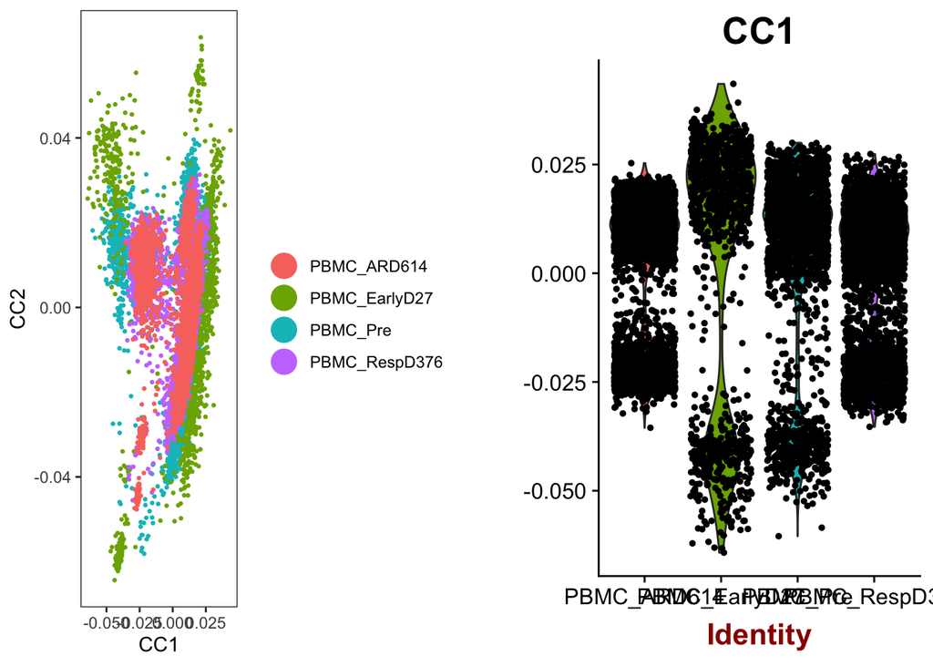

```r
p1 <- DimPlot(object = sce.comb,
              reduction.use = "cca", group.by = "group",
              pt.size = 0.5, do.return = TRUE)
p2 <- VlnPlot(object = sce.comb,
              features.plot = "CC1",
              group.by = "group",
              do.return = TRUE)
plot_grid(p1, p2)
```

```r
#ggsave('patient1-PBMAC.sce.comb_explore_CC.pdf')
PrintDim(object = sce.comb, reduction.type = "cca",
         dims.print = 1:2,
         genes.print = 10)
```

```
## [1] "CC1"
##  [1] "hg38_CST3"   "hg38_S100A9" "hg38_LYZ"    "hg38_FCN1"   "hg38_AIF1"
##  [6] "hg38_LST1"   "hg38_S100A8" "hg38_CSTA"   "hg38_TYROBP" "hg38_CTSS"
## [1] ""
##  [1] "hg38_RPL3"   "hg38_RPL23A" "hg38_RPS27"  "hg38_RPS3"   "hg38_RPSA"
##  [6] "hg38_RPS29"  "hg38_MALAT1" "hg38_RPL31"  "hg38_RPS18"  "hg38_RPL13A"
## [1] ""
## [1] ""
## [1] "CC2"
##  [1] "hg38_NKG7"   "hg38_CST7"   "hg38_CCL5"   "hg38_GZMB"   "hg38_GZMA"
##  [6] "hg38_FGFBP2" "hg38_GNLY"   "hg38_CTSW"   "hg38_GZMH"   "hg38_PRF1"
## [1] ""
##  [1] "hg38_RPL39"   "hg38_RPL18A"  "hg38_HLA-DRA" "hg38_RPL32"
##  [5] "hg38_RPL34"   "hg38_RPL13"   "hg38_RPS23"   "hg38_RPS13"
##  [9] "hg38_RPLP2"   "hg38_RPL11"
## [1] ""
## [1] ""
```

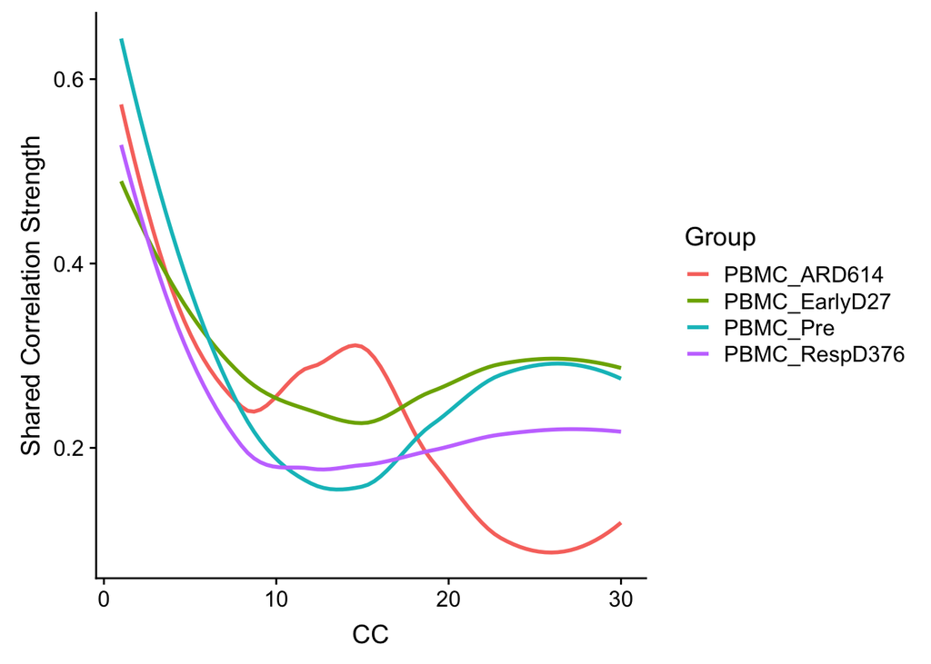

```r
start_time <- Sys.time()
p3 <- MetageneBicorPlot(sce.comb, grouping.var = "group", dims.eval = 1:30,
                        display.progress = FALSE)
```

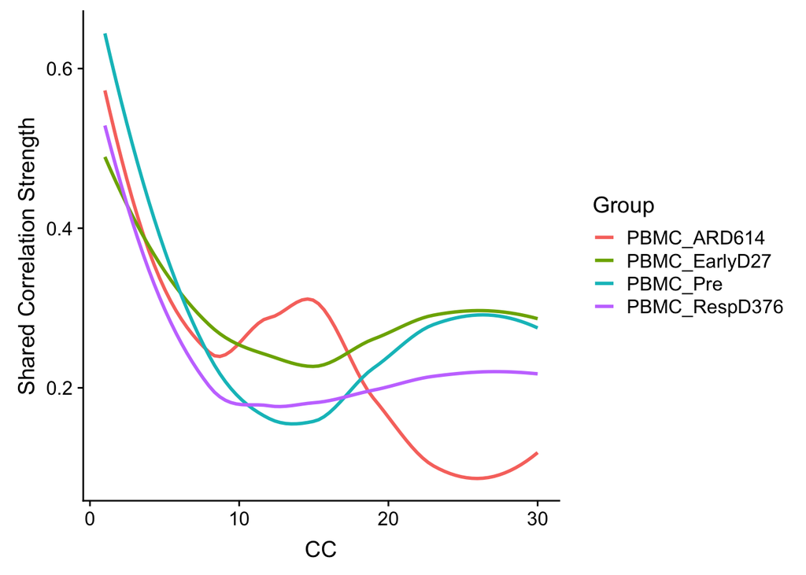

```r
p3
```

```r
end_time <- Sys.time()
end_time - start_time
```

```
## Time difference of 7.894761 mins
```

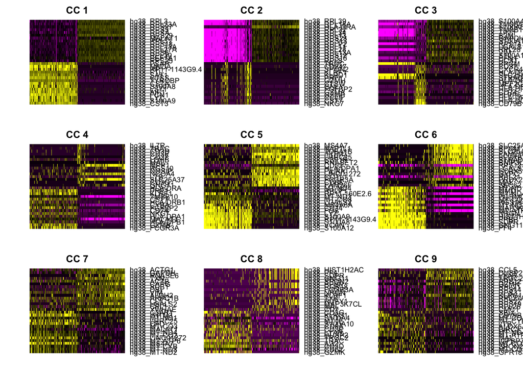

```r
# ggsave('patient1-PBMAC.sce.comb_MetageneBicorPlot.pdf')

DimHeatmap(object = sce.comb, reduction.type = "cca", cells.use = 500,
           dim.use = 1:9, do.balanced = TRUE)
```

```r
# ggsave('patient1-PBMAC.sce.comb_DimHeatmap.pdf')
```

有进度条报告测序运行情况，也需要五分钟。

```r
start_time <- Sys.time()
sce.comb <- AlignSubspace(sce.comb, reduction.type = "cca",
                          grouping.var = "group", verbose =F,
                         dims.align = 1:20)
end_time <- Sys.time()
end_time - start_time
```

```
## Time difference of 5.828849 mins
```

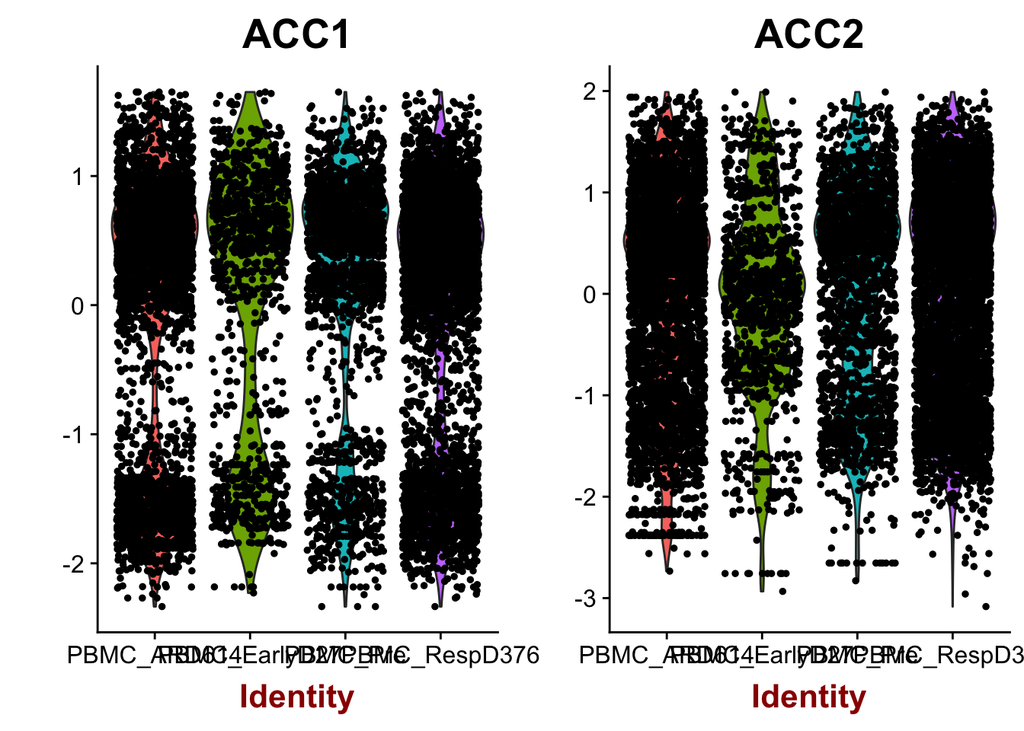

```r
p1 <- VlnPlot(object = sce.comb, features.plot = "ACC1", group.by = "group",
              do.return = TRUE)
p2 <- VlnPlot(object = sce.comb, features.plot = "ACC2", group.by = "group",
              do.return = TRUE)
plot_grid(p1, p2)
```

```r
# ggsave('patient1-PBMAC.sce.comb_ACC.pdf')
```

## t-SNE and Clustering

```r
sce.comb <- RunTSNE(sce.comb, reduction.use = "cca.aligned", dims.use = 1:20,
                   do.fast = T)
sce.comb <- FindClusters(sce.comb, reduction.type = "cca.aligned",
                        resolution = 1, dims.use = 1:20,print.output = 0)
```

## Visualization

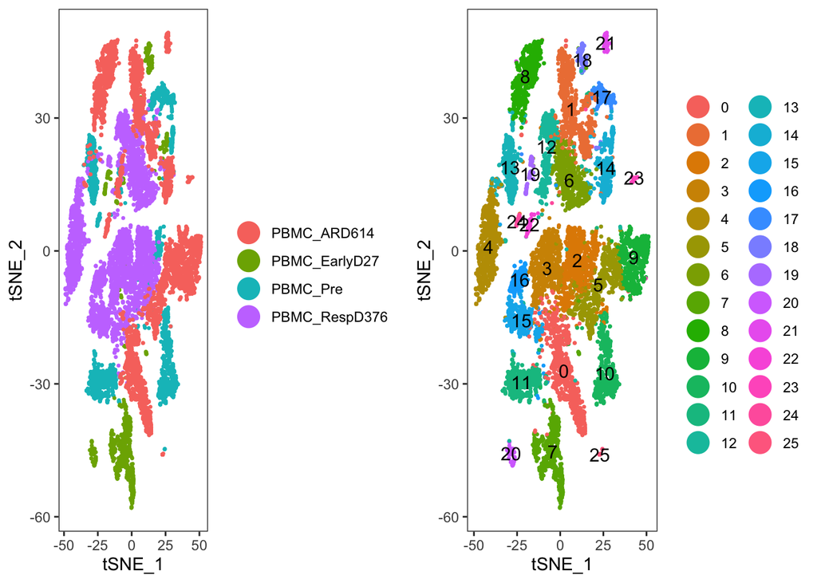

```r
p1 <- TSNEPlot(sce.comb, do.return = T, pt.size = 0.5, group.by = "group")
p2 <- TSNEPlot(sce.comb, do.label = T, do.return = T, pt.size = 0.5)
plot_grid(p1, p2)
```

```r
# ggsave('patient1-PBMAC.sce.comb_tSNE.pdf')

table(sce.comb@meta.data$res.1,sce.comb@meta.data$group)
```

```
##
##      PBMC_ARD614 PBMC_EarlyD27 PBMC_Pre PBMC_RespD376
##   0          802            17       15           152
##   1          694             2       78           128
##   10           2             0      551             1
##   11          10             0      502             0
##   12          90            39       28           296
##   13          39             0      365            45
##   14         238            54       98            37
##   15           0             0        2           393
##   16           2             1        1           209
##   17           0             0      179             2
##   18           0           115        0             0
##   19           0            70        0            36
##   2            6             2      172           686
##   20           0            98        0             0
##   21          90             0        0             0
##   22          78             0        5             1
##   23          48             0        0             0
##   24           0             0       37             0
##   25          25             0        3             0
##   3            2            16        0           786
##   4            0             0        0           770
##   5          629             2        9            99
##   6            0             0        0           668
##   7            0           657        1             2
##   8          641             0        1             0
##   9          629             0        0             0
```

```r
# save(sce.comb,file = 'patient1-PBMAC.sce.comb.second.Rdata')
```